# Midterm

#### 377436: Python Programming III: Data Analysis COM SCI X 418.106 (Winter 2021)

#### Import library, feel free to add any package here if needed

```python
import pandas as pd
import numpy as np
```

### Question 1: Read all 3 data set through `pd.read_csv` from data folder (5 pts)

```python
taster = pd.read_csv("data/taster.csv")
wine = pd.read_csv("data/wine_detail.csv")
winery = pd.read_csv("data/winery_detail.csv")
```

### Question 2: Check shape for each dataset and print them (5 pts)

```python
taster.shape
```

```
(129971, 4)
```

```python
taster
```

|  | Unnamed: 0 | id | taster_name | taster_twitter_handle |
| --- | --- | --- | --- | --- |
| 0 | 0 | 0 | Kerin O’Keefe | @kerinokeefe |
| 1 | 1 | 1 | Roger Voss | @vossroger |
| 2 | 2 | 2 | Paul Gregutt | @paulgwine |
| 3 | 3 | 3 | Alexander Peartree | NaN |
| 4 | 4 | 4 | Paul Gregutt | @paulgwine |
| ... | ... | ... | ... | ... |
| 129966 | 129966 | 129966 | Anna Lee C. Iijima | NaN |
| 129967 | 129967 | 129967 | Paul Gregutt | @paulgwine |
| 129968 | 129968 | 129968 | Roger Voss | @vossroger |
| 129969 | 129969 | 129969 | Roger Voss | @vossroger |
| 129970 | 129970 | 129970 | Roger Voss | @vossroger |

129971 rows × 4 columns

```python
wine.shape
```

```
(129971, 10)
```

```python
wine
```

|  | Unnamed: 0 | id | country | description | designation | points | price | province | region_1 | region_2 |
| --- | --- | --- | --- | --- | --- | --- | --- | --- | --- | --- |
| 0 | 0 | 0 | Italy | Aromas include tropical fruit, broom, brimston... | Vulkà Bianco | 87 | NaN | Sicily & Sardinia | Etna | NaN |
| 1 | 1 | 1 | Portugal | This is ripe and fruity, a wine that is smooth... | Avidagos | 87 | 15.0 | Douro | NaN | NaN |
| 2 | 2 | 2 | US | Tart and snappy, the flavors of lime flesh and... | NaN | 87 | 14.0 | Oregon | Willamette Valley | Willamette Valley |
| 3 | 3 | 3 | US | Pineapple rind, lemon pith and orange blossom ... | Reserve Late Harvest | 87 | 13.0 | Michigan | Lake Michigan Shore | NaN |
| 4 | 4 | 4 | US | Much like the regular bottling from 2012, this... | Vintner's Reserve Wild Child Block | 87 | 65.0 | Oregon | Willamette Valley | Willamette Valley |
| ... | ... | ... | ... | ... | ... | ... | ... | ... | ... | ... |
| 129966 | 129966 | 129966 | Germany | Notes of honeysuckle and cantaloupe sweeten th... | Brauneberger Juffer-Sonnenuhr Spätlese | 90 | 28.0 | Mosel | NaN | NaN |
| 129967 | 129967 | 129967 | US | Citation is given as much as a decade of bottl... | NaN | 90 | 75.0 | Oregon | Oregon | Oregon Other |
| 129968 | 129968 | 129968 | France | Well-drained gravel soil gives this wine its c... | Kritt | 90 | 30.0 | Alsace | Alsace | NaN |
| 129969 | 129969 | 129969 | France | A dry style of Pinot Gris, this is crisp with ... | NaN | 90 | 32.0 | Alsace | Alsace | NaN |
| 129970 | 129970 | 129970 | France | Big, rich and off-dry, this is powered by inte... | Lieu-dit Harth Cuvée Caroline | 90 | 21.0 | Alsace | Alsace | NaN |

129971 rows × 10 columns

```python
winery.shape
```

```
(129971, 5)
```

```python
winery
```

|  | Unnamed: 0 | id | title | variety | winery |
| --- | --- | --- | --- | --- | --- |
| 0 | 0 | 0 | Nicosia 2013 Vulkà Bianco (Etna) | White Blend | Nicosia |
| 1 | 1 | 1 | Quinta dos Avidagos 2011 Avidagos Red (Douro) | Portuguese Red | Quinta dos Avidagos |
| 2 | 2 | 2 | Rainstorm 2013 Pinot Gris (Willamette Valley) | Pinot Gris | Rainstorm |
| 3 | 3 | 3 | St. Julian 2013 Reserve Late Harvest Riesling ... | Riesling | St. Julian |
| 4 | 4 | 4 | Sweet Cheeks 2012 Vintner's Reserve Wild Child... | Pinot Noir | Sweet Cheeks |
| ... | ... | ... | ... | ... | ... |
| 129966 | 129966 | 129966 | Dr. H. Thanisch (Erben Müller-Burggraef) 2013 ... | Riesling | Dr. H. Thanisch (Erben Müller-Burggraef) |
| 129967 | 129967 | 129967 | Citation 2004 Pinot Noir (Oregon) | Pinot Noir | Citation |
| 129968 | 129968 | 129968 | Domaine Gresser 2013 Kritt Gewurztraminer (Als... | Gewürztraminer | Domaine Gresser |
| 129969 | 129969 | 129969 | Domaine Marcel Deiss 2012 Pinot Gris (Alsace) | Pinot Gris | Domaine Marcel Deiss |
| 129970 | 129970 | 129970 | Domaine Schoffit 2012 Lieu-dit Harth Cuvée Car... | Gewürztraminer | Domaine Schoffit |

129971 rows × 5 columns

### Question 3: Merge 3 tables together by primary key `id` (5 pts)

```python
wine_tasting = taster.merge(wine, on = 'id', how = 'left')
```

```python
wine_tasting = wine_tasting.merge(winery, on = 'id', how = 'left')
```

```python
wine_tasting.head()
```

|  | Unnamed: 0_x | id | taster_name | taster_twitter_handle | Unnamed: 0_y | country | description | designation | points | price | province | region_1 | region_2 | Unnamed: 0 | title | variety | winery |
| --- | --- | --- | --- | --- | --- | --- | --- | --- | --- | --- | --- | --- | --- | --- | --- | --- | --- |
| 0 | 0 | 0 | Kerin O’Keefe | @kerinokeefe | 0 | Italy | Aromas include tropical fruit, broom, brimston... | Vulkà Bianco | 87 | NaN | Sicily & Sardinia | Etna | NaN | 0 | Nicosia 2013 Vulkà Bianco (Etna) | White Blend | Nicosia |
| 1 | 1 | 1 | Roger Voss | @vossroger | 1 | Portugal | This is ripe and fruity, a wine that is smooth... | Avidagos | 87 | 15.0 | Douro | NaN | NaN | 1 | Quinta dos Avidagos 2011 Avidagos Red (Douro) | Portuguese Red | Quinta dos Avidagos |
| 2 | 2 | 2 | Paul Gregutt | @paulgwine | 2 | US | Tart and snappy, the flavors of lime flesh and... | NaN | 87 | 14.0 | Oregon | Willamette Valley | Willamette Valley | 2 | Rainstorm 2013 Pinot Gris (Willamette Valley) | Pinot Gris | Rainstorm |
| 3 | 3 | 3 | Alexander Peartree | NaN | 3 | US | Pineapple rind, lemon pith and orange blossom ... | Reserve Late Harvest | 87 | 13.0 | Michigan | Lake Michigan Shore | NaN | 3 | St. Julian 2013 Reserve Late Harvest Riesling ... | Riesling | St. Julian |
| 4 | 4 | 4 | Paul Gregutt | @paulgwine | 4 | US | Much like the regular bottling from 2012, this... | Vintner's Reserve Wild Child Block | 87 | 65.0 | Oregon | Willamette Valley | Willamette Valley | 4 | Sweet Cheeks 2012 Vintner's Reserve Wild Child... | Pinot Noir | Sweet Cheeks |

#### For all questions below, we assume dataframe is the merged one unless it specifies.

### Question 4: Display the dtype/number of entries of the entire merged dataframe (5 pts)

```python
wine_tasting.info()
```

```
<class 'pandas.core.frame.DataFrame'>
Int64Index: 129971 entries, 0 to 129970
Data columns (total 17 columns):
 #   Column                 Non-Null Count   Dtype
---  ------                 --------------   -----
 0   Unnamed: 0_x           129971 non-null  int64
 1   id                     129971 non-null  int64
 2   taster_name            103727 non-null  object
 3   taster_twitter_handle  98758 non-null   object
 4   Unnamed: 0_y           129971 non-null  int64
 5   country                129908 non-null  object
 6   description            129971 non-null  object
 7   designation            92506 non-null   object
 8   points                 129971 non-null  int64
 9   price                  120975 non-null  float64
 10  province               129908 non-null  object
 11  region_1               108724 non-null  object
 12  region_2               50511 non-null   object
 13  Unnamed: 0             129971 non-null  int64
 14  title                  129971 non-null  object
 15  variety                129970 non-null  object
 16  winery                 129971 non-null  object
dtypes: float64(1), int64(5), object(11)
memory usage: 17.8+ MB
```

### Question 5: Calculate the `country` occurrence `percentage ratio` for each wine. List the top 5 and bottom 5 separately (10 pts)

```python
percentage_ratio = wine_tasting['country'].value_counts(normalize=True)
```

```python
percentage_ratio.head()
```

```
US          0.419558
France      0.170067
Italy       0.150414
Spain       0.051152
Portugal    0.043808
Name: country, dtype: float64
```

```python
percentage_ratio.tail()
```

```
Armenia                   0.000015
Bosnia and Herzegovina    0.000015
Slovakia                  0.000008
Egypt                     0.000008
China                     0.000008
Name: country, dtype: float64
```

### Question 6: Calculate average wine price from each `country` and sort it from high to low (10 pts)

```python
avg_price = wine_tasting.groupby("country").agg({"price" : np.mean})
avg_price.rename(columns={"price": "avg_price"}, inplace= True)
```

```python
avg_price.sort_values(by=['avg_price'], ascending = False)
```

| country | avg_price |
| --- | --- |
| Switzerland | 85.285714 |
| England | 51.681159 |
| Germany | 42.257547 |
| France | 41.139120 |
| Hungary | 40.648276 |
| Italy | 39.663770 |
| US | 36.573464 |
| Canada | 35.712598 |
| Australia | 35.437663 |
| Israel | 31.768916 |
| Austria | 30.762772 |
| Lebanon | 30.685714 |
| Spain | 28.215275 |
| New Zealand | 26.931785 |
| Mexico | 26.785714 |
| Uruguay | 26.403670 |
| Portugal | 26.218256 |
| Croatia | 25.450704 |
| Slovenia | 24.812500 |
| South Africa | 24.668987 |
| Turkey | 24.633333 |
| Argentina | 24.510117 |
| Serbia | 24.500000 |
| Czech Republic | 24.250000 |
| Brazil | 23.765957 |
| Luxembourg | 23.333333 |
| Greece | 22.364425 |
| Chile | 20.786458 |
| Morocco | 19.500000 |
| Georgia | 19.321429 |
| Peru | 18.062500 |
| China | 18.000000 |
| Moldova | 16.745763 |
| Cyprus | 16.272727 |
| Slovakia | 16.000000 |
| Macedonia | 15.583333 |
| Romania | 15.241667 |
| Bulgaria | 14.645390 |
| Armenia | 14.500000 |
| India | 13.333333 |
| Bosnia and Herzegovina | 12.500000 |
| Ukraine | 9.214286 |
| Egypt | NaN |

### Question 7: Provide the statistic of `points` and `price` columns; and then sort the data frame by `points` from high to low (10 pts)

```python
wine_tasting.points.describe()
```

```
count    129971.000000
mean         88.447138
std           3.039730
min          80.000000
25%          86.000000
50%          88.000000
75%          91.000000
max         100.000000
Name: points, dtype: float64
```

```python
wine_tasting.price.describe()
```

```
count    120975.000000
mean         35.363389
std          41.022218
min           4.000000
25%          17.000000
50%          25.000000
75%          42.000000
max        3300.000000
Name: price, dtype: float64
```

```python
wine_tasting.sort_values(by=['points'], ascending = False)
```

|  | Unnamed: 0_x | id | taster_name | taster_twitter_handle | Unnamed: 0_y | country | description | designation | points | price | province | region_1 | region_2 | Unnamed: 0 | title | variety | winery |
| --- | --- | --- | --- | --- | --- | --- | --- | --- | --- | --- | --- | --- | --- | --- | --- | --- | --- |
| 114972 | 114972 | 114972 | Roger Voss | @vossroger | 114972 | Portugal | A powerful and ripe wine, strongly influenced ... | Nacional Vintage | 100 | 650.0 | Port | NaN | NaN | 114972 | Quinta do Noval 2011 Nacional Vintage (Port) | Port | Quinta do Noval |
| 89729 | 89729 | 89729 | Roger Voss | @vossroger | 89729 | France | This new release from a great vintage for Char... | Le Mesnil Blanc de Blancs Brut | 100 | 617.0 | Champagne | Champagne | NaN | 89729 | Salon 2006 Le Mesnil Blanc de Blancs Brut Char... | Chardonnay | Salon |
| 113929 | 113929 | 113929 | Paul Gregutt | @paulgwine | 113929 | US | In 2005 Charles Smith introduced three high-en... | Royal City | 100 | 80.0 | Washington | Columbia Valley (WA) | Columbia Valley | 113929 | Charles Smith 2006 Royal City Syrah (Columbia ... | Syrah | Charles Smith |
| 45781 | 45781 | 45781 | Kerin O’Keefe | @kerinokeefe | 45781 | Italy | This gorgeous, fragrant wine opens with classi... | Riserva | 100 | 550.0 | Tuscany | Brunello di Montalcino | NaN | 45781 | Biondi Santi 2010 Riserva (Brunello di Montal... | Sangiovese | Biondi Santi |
| 123545 | 123545 | 123545 | Paul Gregutt | @paulgwine | 123545 | US | Initially a rather subdued Frog; as if it has ... | Bionic Frog | 100 | 80.0 | Washington | Walla Walla Valley (WA) | Columbia Valley | 123545 | Cayuse 2008 Bionic Frog Syrah (Walla Walla Val... | Syrah | Cayuse |
| ... | ... | ... | ... | ... | ... | ... | ... | ... | ... | ... | ... | ... | ... | ... | ... | ... | ... |
| 128255 | 128255 | 128255 | Michael Schachner | @wineschach | 128255 | Argentina | Severely compromised by green, minty, weedy ar... | NaN | 80 | 13.0 | Mendoza Province | Mendoza | NaN | 128255 | Viniterra 2007 Malbec (Mendoza) | Malbec | Viniterra |
| 128254 | 128254 | 128254 | Michael Schachner | @wineschach | 128254 | Argentina | Disappointing considering the source. The nose... | Gran Lurton | 80 | 20.0 | Mendoza Province | Mendoza | NaN | 128254 | François Lurton 2006 Gran Lurton Cabernet Sauv... | Cabernet Sauvignon | François Lurton |
| 93686 | 93686 | 93686 | Michael Schachner | @wineschach | 93686 | Peru | Best on the nose, where apple and lemony aroma... | Brut | 80 | 15.0 | Ica | NaN | NaN | 93686 | Tacama 2010 Brut Sparkling (Ica) | Sparkling Blend | Tacama |
| 73865 | 73865 | 73865 | Joe Czerwinski | @JoeCz | 73865 | Chile | There's not much point in making a reserve-sty... | Prima Reserva | 80 | 13.0 | Maipo Valley | NaN | NaN | 73865 | De Martino 1999 Prima Reserva Merlot (Maipo Va... | Merlot | De Martino |
| 128256 | 128256 | 128256 | NaN | NaN | 128256 | US | A hot, harsh and unbalance Chardonnay. Barely ... | NaN | 80 | 24.0 | California | Contra Costa County | Central Coast | 128256 | Bloomfield 2008 Chardonnay (Contra Costa County) | Chardonnay | Bloomfield |

129971 rows × 17 columns

### Question 8: How many different tasters are in this data frame (`ignore nan`)? (5 pts)

```python
wine_tasting['taster_name'].nunique()
```

```
19
```

### Question 9: What is the average `points` giving out from each `taster`? (10 pts)

```python
avg_taster_points = wine_tasting.groupby("taster_name").agg({"points" : np.mean})
avg_taster_points.rename(columns={"points": "avg_points"}, inplace= True)
```

```python
avg_taster_points
```

| taster_name | avg_points |
| --- | --- |
| Alexander Peartree | 85.855422 |
| Anna Lee C. Iijima | 88.415629 |
| Anne Krebiehl MW | 90.562551 |
| Carrie Dykes | 86.395683 |
| Christina Pickard | 87.833333 |
| Fiona Adams | 86.888889 |
| Jeff Jenssen | 88.319756 |
| Jim Gordon | 88.626287 |
| Joe Czerwinski | 88.536235 |
| Kerin O’Keefe | 88.867947 |
| Lauren Buzzeo | 87.739510 |
| Matt Kettmann | 90.008686 |
| Michael Schachner | 86.907493 |
| Mike DeSimone | 89.101167 |
| Paul Gregutt | 89.082564 |
| Roger Voss | 88.708003 |
| Sean P. Sullivan | 88.755739 |
| Susan Kostrzewa | 86.609217 |
| Virginie Boone | 89.213379 |

### Question 10: Customized points (35 pts)

Now let's say, we now want to build a customized point system which using the text data in `description` column to generate a `customized_points`. The detailed steps are as following:

1. For each description, we make every char in lower case and split by space, also remove all commas and periods from the text. (5 pts)
2. Remove `stopword`. In Natural language process, we treat 'a', 'the', 'there', etc. as stopword and usually ignore them from our analysis. [Wiki: stopword](https://en.wikipedia.org/wiki/Stop_word)
3. We have some predefined stopword dictionary, so please run the two cells below to install `nltk` and download the stopword list. And after installing, running the third cell below will print the stopword list for you.
4. Back the the logic. We now need to ignore word in provided stopword list and create a counter for each vocabulary. (15 pts)
5. For top 10 frequent words, if any one of those is showed in the `description`, it represents 10 points. So as a result, if a wine `description` has all 10 frequent word, we will assign it to be the best wine in the world with 100 points. (15 pts)

```python
%pip install nltk
```

```python
import nltk
nltk.download('stopwords')
```

```
True
```

```python
from nltk.corpus import stopwords
stop_words = set(stopwords.words('english'))
print(f'stop word list: {stop_words}')
```

```
stop word list: {'y', 'herself', 'couldn', 'm', "wouldn't", "don't", 'very', 've', 'and', 'been', 'or', 'now', 'having', 'over', 'for', 'as', 'too', 'his', 'shan', 'whom', 'by', 'we', 'were', 'out', 'that', 'our', 'why', 'while', 'yourself', "you're", 'himself', 'once', 'him', 'did', 'under', 'at', …
```

```python
wine_tasting['description'] = wine_tasting.description.str.replace("[^\w\s]", "").str.lower()
wine_tasting['description'] = wine_tasting['description'].apply(lambda x: ' '.join([item for item in x.split() if item not in stop_words]))


from collections import Counter
word_count = Counter()
wine_tasting['description'].str.lower().str.split().apply(word_count.update)
```

```
0         None
1         None
2         None
3         None
4         None
          ...
129966    None
129967    None
129968    None
129969    None
129970    None
Name: description, Length: 129971, dtype: object
```

```python
top_ten = word_count.most_common(10)
top_ten = list([item[0] for item in top_ten])
```

```python
top_ten
```

```
['wine',
 'flavors',
 'fruit',
 'aromas',
 'palate',
 'acidity',
 'finish',
 'tannins',
 'drink',
 'cherry']
```

```python
wine_tasting['top_word_occurrences'] = wine_tasting['description'].str.count(r'\b|\b'.join(top_ten))
wine_tasting['customized_points'] = wine_tasting['top_word_occurrences']*10
```

```python
wine_tasting.sort_values(by=['customized_points'], ascending = False)
```

|  | Unnamed: 0_x | id | taster_name | taster_twitter_handle | Unnamed: 0_y | country | description | designation | points | price | province | region_1 | region_2 | Unnamed: 0 | title | variety | winery | top_word_occurrences | customized_points |
| --- | --- | --- | --- | --- | --- | --- | --- | --- | --- | --- | --- | --- | --- | --- | --- | --- | --- | --- | --- |
| 72157 | 72157 | 72157 | Mike DeSimone | @worldwineguys | 72157 | Israel | aromas black cherry raspberry flint smoke viol... | Yasmin | 90 | 12.0 | Galilee | NaN | NaN | 72157 | Recanati 2014 Yasmin Red (Galilee) | Red Blend | Recanati | 12 | 120 |
| 77228 | 77228 | 77228 | Lauren Buzzeo | @laurbuzz | 77228 | South Africa | winemaker abrie beeslaar seductive streak pres... | Cape Winemakers Guild CWG | 93 | NaN | Simonsberg-Stellenbosch | NaN | NaN | 77228 | Kanonkop 2014 Cape Winemakers Guild CWG Pinota... | Pinotage | Kanonkop | 12 | 120 |
| 13051 | 13051 | 13051 | Lauren Buzzeo | @laurbuzz | 13051 | South Africa | blend 60 cabernet sauvignon 20 shiraz 5 merlot... | Proprietor's | 90 | 38.0 | Stellenbosch | NaN | NaN | 13051 | Ernie Els 2014 Proprietor's Red (Stellenbosch) | Red Blend | Ernie Els | 11 | 110 |
| 97446 | 97446 | 97446 | Paul Gregutt | @paulgwine | 97446 | US | dark dusty strongly scented barrel toast coffe... | NaN | 91 | 45.0 | Washington | Columbia Valley (WA) | Columbia Valley | 97446 | Saggi 2007 Red (Columbia Valley (WA)) | Red Blend | Saggi | 11 | 110 |
| 53515 | 53515 | 53515 | NaN | NaN | 53515 | US | true clos du val paradigm wine offers ripe cal... | Single Vineyard | 89 | 26.0 | California | Carneros | Napa-Sonoma | 53515 | Clos du Val 1998 Single Vineyard Pinot Noir (C... | Pinot Noir | Clos du Val | 11 | 110 |
| ... | ... | ... | ... | ... | ... | ... | ... | ... | ... | ... | ... | ... | ... | ... | ... | ... | ... | ... | ... |
| 14318 | 14318 | 14318 | Paul Gregutt | @paulgwine | 14318 | US | reserve begins vineyardblock selection spends ... | Reserve | 92 | 45.0 | Oregon | Dundee Hills | Willamette Valley | 14318 | The Four Graces 2014 Reserve Pinot Noir (Dunde... | Pinot Noir | The Four Graces | 0 | 0 |
| 65131 | 65131 | 65131 | Virginie Boone | @vboone | 65131 | US | peppery tasting freshly picked blackberries ha... | Old Vine | 87 | 20.0 | California | Lodi | Central Valley | 65131 | Haraszthy 2010 Old Vine Zinfandel (Lodi) | Zinfandel | Haraszthy | 0 | 0 |
| 126724 | 126724 | 126724 | Virginie Boone | @vboone | 126724 | US | aromatic honeysuckletinged coolclimate white l... | Dry Estate Bottled | 90 | 20.0 | California | Anderson Valley | NaN | 126724 | Navarro 2011 Dry Estate Bottled Gewürztraminer... | Gewürztraminer | Navarro | 0 | 0 |
| 3678 | 3678 | 3678 | NaN | NaN | 3678 | US | old saying get pay perfectly illustrated simpl... | NaN | 84 | 9.0 | California | California | California Other | 3678 | Lucky Star 2009 Pinot Noir (California) | Pinot Noir | Lucky Star | 0 | 0 |
| 26272 | 26272 | 26272 | Anne Krebiehl MW | @AnneInVino | 26272 | Austria | red apple savory yeast zesty lemon unite white... | Gemischter Satz | 88 | NaN | Niederösterreich | NaN | NaN | 26272 | Martinshof 2015 Gemischter Satz White (Niederö... | White Blend | Martinshof | 0 | 0 |

129971 rows × 19 columns

```python
best_wine = wine_tasting[(wine_tasting['customized_points'] >= 100)]
best_wine
```

|  | Unnamed: 0_x | id | taster_name | taster_twitter_handle | Unnamed: 0_y | country | description | designation | points | price | province | region_1 | region_2 | Unnamed: 0 | title | variety | winery | top_word_occurrences | customized_points |
| --- | --- | --- | --- | --- | --- | --- | --- | --- | --- | --- | --- | --- | --- | --- | --- | --- | --- | --- | --- |
| 3072 | 3072 | 3072 | Roger Voss | @vossroger | 3072 | France | aromas smoky new wood follow wood flavors pala... | Clos des Mouches Premier Cru | 94 | 89.0 | Burgundy | Beaune | NaN | 3072 | Joseph Drouhin 2008 Clos des Mouches Premier C... | Pinot Noir | Joseph Drouhin | 10 | 100 |
| 4896 | 4896 | 4896 | Mike DeSimone | @worldwineguys | 4896 | Lebanon | violet red eye wine blend 55 syrah 35 cabernet... | El | 91 | 75.0 | Lebanon | NaN | NaN | 4896 | Ixsir 2011 El Red (Lebanon) | Red Blend | Ixsir | 10 | 100 |
| 6345 | 6345 | 6345 | Jim Gordon | @gordone_cellars | 6345 | US | gorgeous fruit aromas generous deep fruit flav... | Old Vine Rinaldi Vineyard | 93 | 30.0 | California | Fiddletown | Sierra Foothills | 6345 | Easton 2012 Old Vine Rinaldi Vineyard Zinfande... | Zinfandel | Easton | 10 | 100 |
| 13051 | 13051 | 13051 | Lauren Buzzeo | @laurbuzz | 13051 | South Africa | blend 60 cabernet sauvignon 20 shiraz 5 merlot... | Proprietor's | 90 | 38.0 | Stellenbosch | NaN | NaN | 13051 | Ernie Els 2014 Proprietor's Red (Stellenbosch) | Red Blend | Ernie Els | 11 | 110 |
| 14514 | 14514 | 14514 | Mike DeSimone | @worldwineguys | 14514 | Israel | deep black cherry color wine offers aromas bla... | Hommage | 88 | 38.0 | Ella Valley | NaN | NaN | 14514 | Yaffo 2014 Hommage Syrah-Merlot (Ella Valley) | Syrah-Merlot | Yaffo | 10 | 100 |
| 15207 | 15207 | 15207 | Jim Gordon | @gordone_cellars | 15207 | US | fruitdriven baxter 2013s wine beautiful bright... | Ferrington Vineyard | 94 | 52.0 | California | Anderson Valley | NaN | 15207 | Baxter 2013 Ferrington Vineyard Pinot Noir (An... | Pinot Noir | Baxter | 10 | 100 |
| 18236 | 18236 | 18236 | Jim Gordon | @gordone_cellars | 18236 | US | seductive wine aromas mint cassis leading deli... | Contento Vineyard Estate Bottled | 92 | 30.0 | California | Mendocino | NaN | 18236 | Brutocao 2014 Contento Vineyard Estate Bottled... | Cabernet Sauvignon | Brutocao | 10 | 100 |
| 28120 | 28120 | 28120 | Joe Czerwinski | @JoeCz | 28120 | Australia | ripe black cherry cedary aromas cant hide touc... | Hickinbotham | 90 | 65.0 | South Australia | Clarendon | NaN | 28120 | Clarendon Hills 2005 Hickinbotham Grenache (Cl... | Grenache | Clarendon Hills | 10 | 100 |
| 30829 | 30829 | 30829 | Fiona Adams | @bkfiona | 30829 | US | spicy aromas cedar pepper joined warm notes bl... | NaN | 87 | 35.0 | Colorado | Colorado | NaN | 30829 | Creekside Cellars 2014 Cabernet Sauvignon (Col... | Cabernet Sauvignon | Creekside Cellars | 10 | 100 |
| 38862 | 38862 | 38862 | Lauren Buzzeo | @laurbuzz | 38862 | France | ecofriendly wine demure elegant nose mediumint... | NaN | 90 | 17.0 | Languedoc-Roussillon | Saint-Chinian | NaN | 38862 | Château Veronique 2012 Carignan-Grenache (Sain... | Carignan-Grenache | Château Veronique | 10 | 100 |
| 53515 | 53515 | 53515 | NaN | NaN | 53515 | US | true clos du val paradigm wine offers ripe cal... | Single Vineyard | 89 | 26.0 | California | Carneros | Napa-Sonoma | 53515 | Clos du Val 1998 Single Vineyard Pinot Noir (C... | Pinot Noir | Clos du Val | 11 | 110 |
| 57614 | 57614 | 57614 | Lauren Buzzeo | @laurbuzz | 57614 | South Africa | winemaker etienne le riche layers aromas flavo... | Cape Winemakers Guild CWG Auction Reserve | 92 | NaN | Stellenbosch | NaN | NaN | 57614 | Etienne le Riche 2014 Cape Winemakers Guild CW... | Cabernet Sauvignon | Etienne le Riche | 10 | 100 |
| 58840 | 58840 | 58840 | Mike DeSimone | @worldwineguys | 58840 | Israel | dark red violet color wine aromas cherry laven... | Reserve | 91 | 25.0 | Upper Galilee | NaN | NaN | 58840 | Binyamina 2012 Reserve Cabernet Sauvignon (Upp... | Cabernet Sauvignon | Binyamina | 10 | 100 |
| 65111 | 65111 | 65111 | Roger Voss | @vossroger | 65111 | France | still firm tannins also rich generous wine min... | NaN | 91 | 30.0 | Bordeaux | Saint-Estèphe | NaN | 65111 | Château Bel-Air Ortet 2012 Saint-Estèphe | Bordeaux-style Red Blend | Château Bel-Air Ortet | 10 | 100 |
| 68059 | 68059 | 68059 | Mike DeSimone | @worldwineguys | 68059 | Israel | offering aromas blackberry strawberry green be... | Adi 13 | 88 | 9.0 | Israel | NaN | NaN | 68059 | Hacormim 2014 Adi 13 Merlot (Israel) | Merlot | Hacormim | 10 | 100 |
| 70578 | 70578 | 70578 | Jim Gordon | @gordone_cellars | 70578 | US | great balance snappy acidity concentrated frui... | Oppenlander Vineyard | 94 | 44.0 | California | Mendocino County | NaN | 70578 | Waits-Mast 2012 Oppenlander Vineyard Pinot Noi... | Pinot Noir | Waits-Mast | 10 | 100 |
| 70988 | 70988 | 70988 | Michael Schachner | @wineschach | 70988 | Chile | olive herb earth aromas vie foresty fruit arom... | Sideral | 90 | 31.0 | Rapel Valley | NaN | NaN | 70988 | Altaïr 2006 Sideral Red (Rapel Valley) | Cabernet Blend | Altaïr | 10 | 100 |
| 72157 | 72157 | 72157 | Mike DeSimone | @worldwineguys | 72157 | Israel | aromas black cherry raspberry flint smoke viol... | Yasmin | 90 | 12.0 | Galilee | NaN | NaN | 72157 | Recanati 2014 Yasmin Red (Galilee) | Red Blend | Recanati | 12 | 120 |
| 76292 | 76292 | 76292 | Jim Gordon | @gordone_cellars | 76292 | US | wine rich almost sweet fruit aromas vivid frui... | Weir Vineyard | 92 | 58.0 | California | Yorkville Highlands | North Coast | 76292 | Williams Selyem 2013 Weir Vineyard Pinot Noir ... | Pinot Noir | Williams Selyem | 10 | 100 |
| 77228 | 77228 | 77228 | Lauren Buzzeo | @laurbuzz | 77228 | South Africa | winemaker abrie beeslaar seductive streak pres... | Cape Winemakers Guild CWG | 93 | NaN | Simonsberg-Stellenbosch | NaN | NaN | 77228 | Kanonkop 2014 Cape Winemakers Guild CWG Pinota... | Pinotage | Kanonkop | 12 | 120 |
| 80955 | 80955 | 80955 | Roger Voss | @vossroger | 80955 | France | redjelly aromas followed wine tannins soft tex... | NaN | 86 | NaN | Bordeaux | Cadillac Côtes de Bordeaux | NaN | 80955 | Château de Marsan 2014 Cadillac Côtes de Bord... | Bordeaux-style Red Blend | Château de Marsan | 10 | 100 |
| 84316 | 84316 | 84316 | Michael Schachner | @wineschach | 84316 | Spain | blackberry cherry earthy aromas backed seconda... | Pinyolet Selección | 88 | 19.0 | Catalonia | Montsant | NaN | 84316 | Compañia de Vinos del Atlántico 2011 Pinyolet ... | Red Blend | Compañia de Vinos del Atlántico | 10 | 100 |
| 86053 | 86053 | 86053 | NaN | NaN | 86053 | US | fine aromas sour cherry violets spice open lig... | Freedom Hill Vineyard | 89 | 30.0 | Oregon | Willamette Valley | Willamette Valley | 86053 | Bethel Heights 1998 Freedom Hill Vineyard Pino... | Pinot Noir | Bethel Heights | 10 | 100 |
| 87858 | 87858 | 87858 | Mike DeSimone | @worldwineguys | 87858 | Israel | offering aromas blackberry strawberry green be... | Adi 13 | 88 | 9.0 | Israel | NaN | NaN | 87858 | Hacormim 2014 Adi 13 Merlot (Israel) | Merlot | Hacormim | 10 | 100 |
| 93396 | 93396 | 93396 | Sean P. Sullivan | @wawinereport | 93396 | US | wine mostly cabernet sauvignon 85 along 9 peti... | NaN | 92 | 125.0 | Washington | Washington | Washington Other | 93396 | 21 Grams 2011 Red (Washington) | Bordeaux-style Red Blend | 21 Grams | 10 | 100 |
| 95923 | 95923 | 95923 | Mike DeSimone | @worldwineguys | 95923 | Israel | aromas black cherry green frying peppers prepa... | Adama | 87 | 22.0 | Galilee | NaN | NaN | 95923 | Tabor 2011 Adama Merlot (Galilee) | Merlot | Tabor | 10 | 100 |
| 97446 | 97446 | 97446 | Paul Gregutt | @paulgwine | 97446 | US | dark dusty strongly scented barrel toast coffe... | NaN | 91 | 45.0 | Washington | Columbia Valley (WA) | Columbia Valley | 97446 | Saggi 2007 Red (Columbia Valley (WA)) | Red Blend | Saggi | 11 | 110 |
| 101963 | 101963 | 101963 | Mike DeSimone | @worldwineguys | 101963 | Israel | aromas black cherry green frying peppers prepa... | Adama | 87 | 22.0 | Galilee | NaN | NaN | 101963 | Tabor 2011 Adama Merlot (Galilee) | Merlot | Tabor | 10 | 100 |
| 103592 | 103592 | 103592 | Lauren Buzzeo | @laurbuzz | 103592 | South Africa | wine densely packed ripe redfruit aromas flavo... | Freedom | 91 | 42.0 | Elgin | NaN | NaN | 103592 | Radford Dale 2012 Freedom Pinot Noir (Elgin) | Pinot Noir | Radford Dale | 10 | 100 |
| 103686 | 103686 | 103686 | Mike DeSimone | @worldwineguys | 103686 | Israel | inky redviolet eye wine nose chocolate covered... | NaN | 90 | 17.0 | Galilee | NaN | NaN | 103686 | Recanati 2014 Merlot (Galilee) | Merlot | Recanati | 10 | 100 |
| 112790 | 112790 | 112790 | Michael Schachner | @wineschach | 112790 | Spain | maturing wine aromas burnt leaves dill leather... | Crianza | 87 | 15.0 | Northern Spain | Ribera del Duero | NaN | 112790 | Condado de Oriza 2003 Crianza (Ribera del Duero) | Tempranillo | Condado de Oriza | 10 | 100 |
| 115207 | 115207 | 115207 | Mike DeSimone | @worldwineguys | 115207 | Israel | wine aromas cherry violet acidity silky tannin... | Mosaic | 91 | 70.0 | Judean Hills | NaN | NaN | 115207 | Shiloh Winery 2013 Mosaic Red (Judean Hills) | Bordeaux-style Red Blend | Shiloh Winery | 10 | 100 |
| 115335 | 115335 | 115335 | Anne Krebiehl MW | @AnneInVino | 115335 | France | wine carries aromas white blossom dusk freshly... | Wiebelsberg Grand Cru | 94 | 55.0 | Alsace | Alsace | NaN | 115335 | Domaine Gresser 2012 Wiebelsberg Grand Cru Rie... | Riesling | Domaine Gresser | 10 | 100 |
| 116567 | 116567 | 116567 | Michael Schachner | @wineschach | 116567 | Spain | blackberry cherry earthy aromas backed seconda... | Pinyolet Selección | 88 | 19.0 | Catalonia | Montsant | NaN | 116567 | Compañia de Vinos del Atlántico 2011 Pinyolet ... | Red Blend | Compañia de Vinos del Atlántico | 10 | 100 |
| 119664 | 119664 | 119664 | Anne Krebiehl MW | @AnneInVino | 119664 | Austria | dark red blackcherry fruit clothed sumptuous p... | Diabas Reserve | 95 | 55.0 | Eisenberg | NaN | NaN | 119664 | Jalits 2013 Diabas Reserve Blaufränkisch (Eise... | Blaufränkisch | Jalits | 10 | 100 |
| 128375 | 128375 | 128375 | Jim Gordon | @gordone_cellars | 128375 | US | sleek wine carries ripe complex fruit aromas d... | Flutist Sea of Grapes Vineyard | 93 | 40.0 | California | Amador County | Sierra Foothills | 128375 | Renwood 2012 Flutist Sea of Grapes Vineyard Zi... | Zinfandel | Renwood | 10 | 100 |

### Bouns Question: plot the distribution plot of `price` (5 pts)

`Hint`: [reference](https://pandas.pydata.org/pandas-docs/stable/reference/api/pandas.DataFrame.plot.hist.html)

```python
%matplotlib inline
```

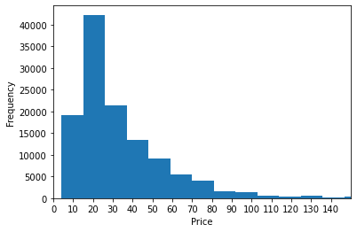

```python
ax = wine_tasting['price'].plot.hist(bins = 300, xlim=(0,150), xticks = np.arange(0, 150, 10))
ax.set_xlabel('Price')
```